# Data Wrangling and Graphing in R

## Part One

The first part of our project revolves around doing some data wrangling. The first objective is to simply find how many unique users are included in our dataset. Before looking into this, however, we need to grab the data and display the top 6 rows to see how it looks.

```r
#Loading data into R
pd <- read.csv("Project2Data.csv")

head(pd)
```

```
##   ï..attemptdate attemptresult  userid       type maxsessionuid
## 1  3/1/2020 0:01     SYSLOGOUT HBA1633    EXPRESS        873258
## 2  3/1/2020 1:01     SYSLOGOUT HBA2266    LIMITED        873665
## 3  3/1/2020 1:02     SYSLOGOUT HBA1758 AUTHORIZED        873787
## 4  3/1/2020 1:02     SYSLOGOUT HBA1726    LIMITED        873366
## 5  3/1/2020 1:11         LOGIN HBA1659    LIMITED        873260
## 6  3/1/2020 1:41       TIMEOUT HBA1659    LIMITED        873260
```

To find how many unique users are featured in this data we will simply use the unique() function in base R.

```r
  #Creation of factor showing all unique user IDs
  uniqueusers <- unique(pd$userid)

  #Show's amount of unique user IDs
  length(uniqueusers)
```

```
## [1] 763
```

Next we need to see how many unique users are within each unique user type.

```r
  #Subsets data from pd where user ID is unique
  pd_deduced <- pd[!duplicated(pd[c("userid")]),]

  #Shows how many entries from pd_deduced are in each type of account
  table(pd_deduced$type)
```

```
##
## AUTHORIZED    EXPRESS    LIMITED
##        141        196        426
```

Finally the third section of part one. Here we need to determine the average session length for each unique user type. To do this we will make a new data frame (q3) that is going to show each unique session and display the user associated with it, their classification, the time the logged in and the time their session ended.

```r
  #Subsets data from pd where attempt result is login, timeout or logout into their own data frames
  login <- pd[pd$attemptresult=="LOGIN",]
  logout <- pd[pd$attemptresult=="LOGOUT",]
  timeout <- pd[pd$attemptresult=="TIMEOUT",]

  #Merges subsetted data from above data frames together
  one <- merge(login,logout,by=c("maxsessionuid","userid","type"),all.x=TRUE)
  final <- merge(one,timeout,by=c("maxsessionuid","userid","type"),all.x=TRUE)

  #Renaming columns in 'final' data frame created above
  names(final)[4] <- "login"
  names(final)[5] <- "event1"
  names(final)[6] <- "logout"
  names(final)[7] <- "event2"
  names(final)[8] <- "timeout"
  names(final)[9] <- "event3"

  #Taking necessary columns from 'final' data frame and adding them to created 'q3' data frame
q3 <- data.frame(final$maxsessionuid,final$userid,final$type,
                 mdy_hm(final$login),mdy_hm(final$logout),
                 mdy_hm(final$timeout))

  #Renaming columns in 'q3' data frame created above
  names(q3)[1] <- "maxsessionuid"
  names(q3)[2] <- "userid"
  names(q3)[3] <- "type"
  names(q3)[4] <- "login"
  names(q3)[5] <- "logout"
  names(q3)[6] <- "timeout"

  head(q3)
```

```
##   maxsessionuid  userid       type               login              logout
## 1        873260 HBA1659    LIMITED 2020-03-01 01:11:00                <NA>
## 2        873490 HBA1824 AUTHORIZED 2020-03-01 02:11:00                <NA>
## 3        873893 HBA1789    LIMITED 2020-03-01 02:23:00                <NA>
## 4        873902 HBA1726    LIMITED 2020-03-01 03:11:00 2020-03-01 03:28:00
## 5        873903 HBA1885    LIMITED 2020-03-01 03:12:00 2020-03-01 03:17:00
## 6        873904 HBA2254    EXPRESS 2020-03-01 04:51:00                <NA>
##               timeout
## 1 2020-03-01 01:41:00
## 2 2020-03-01 02:42:00
## 3 2020-03-01 02:57:00
## 4                <NA>
## 5                <NA>
## 6 2020-03-01 05:21:00
```

Next we will find the time each session ended and put it back in the q3 data frame in a new column we’ll call ‘max’. Then we will create another column in that data frame showing the length of each session and call it ‘diff’.

```r
#Finds max time from time fields in q3 and adds them to q3 in new column 'max'
  x <- data.frame(as.numeric(as.POSIXct(q3$login)),as.numeric(as.POSIXct(q3$logout)),
                as.numeric(as.POSIXct(q3$timeout)))
  x[is.na(x)] <- 0
  q3$max <- as_datetime(apply(x,1,max))

  #Creates new column in q3 named 'diff' showing length of each session
  q3$diff <- difftime(q3$max,q3$login,units="hours")
```

To finish out part one we will create three new data frames and vectors for each unique user type. We will use the data frames to find the average difference for each type and then paste the results into the type’s respective vector. This information will go into a new data frame (q3final) which will contain our final result.

```r
  #Subsets data from q3 by type of user access
  q3auth <- q3[q3$type=="AUTHORIZED",]
  q3lim <- q3[q3$type=="LIMITED",]
  q3exp <- q3[q3$type=="EXPRESS",]

  #Finds average length of session for each type of user access
  a <- c(mean(q3auth$diff))
  b <- c(mean(q3lim$diff))
  c <- c(mean(q3exp$diff))

  #Assigns average for each user type to a vector
  AUTHORIZED <- c(paste(floor(a),round((a-floor(a))*60),sep=":"))
  LIMITED <- c(paste(floor(b),round((b-floor(b))*60),sep=":"))
  EXPRESS <- c(paste(floor(c),round((c-floor(c))*60),sep=":"))

  #Adds vectors created above to data frame showing average length of session for each user ID
  q3final <- data.frame(AUTHORIZED,LIMITED,EXPRESS)

  #Renames row in 'q3final' data frame
  row.names(q3final) <- "Average Length of Session"

  #Displays 'q3final' data frame
  q3final
```

```
##                           AUTHORIZED LIMITED EXPRESS
## Average Length of Session       0:39    0:29    0:26
```

## Part Two

In part two of this project we will work on ways to display the data in useful ways. The assignment requests that we create a Gantt chart showing blocks of time representing when each user logged in, mapped on the time field, colored by which user type they belong to.

First we will go ahead and create the Gantt chart as best we can.

In order to do that we need to split our data into smaller, more manageable data frames. We will order out ‘q3’ data frame from the last part by login and then split that data into smaller parts. Order those parts by user ID, and then make new data frames taking only the columns necessary for our Gantt chart. Then we will split one of those data frames into a much smaller data frame for use in our Gantt chart.

```r
  #Subsets data from 'q3' data frame ordering data by login time
  q32 <- q3[order(login),]

  #Breaks out data from each week into it's own data frame
  p1 <- q32[1:6488,]
  p2 <- q32[6489:12112,]
  p3 <- q32[12113:18062,]
  p4 <- q32[18063:26459,]

  #Orders data from data frames created above by user ID
  p1a <- p1[order(p1$userid),]
  p2a <- p1[order(p2$userid),]
  p3a <- p1[order(p3$userid),]
  p4a <- p1[order(p4$userid),]

  #Takes necessary columns from data frames created above and adds them to a new data frame
  p1b <- data.frame(p1a$userid,p1a$type,p1a$maxsessionuid,p1a$login,p1a$max)
  p2b <- data.frame(p2a$userid,p2a$type,p2a$maxsessionuid,p2a$login,p2a$max)
  p3b <- data.frame(p3a$userid,p3a$type,p3a$maxsessionuid,p3a$login,p3a$max)
  p4b <- data.frame(p4a$userid,p4a$type,p4a$maxsessionuid,p4a$login,p4a$max)

  #Subsets data from 'p1b' data frame created above into manageable group of user IDs
  p1ba <- p1b[1:336,]
```

Now, we will create our Gantt chart!

[figure not shown]

```r
  #Creates Gantt chart for group of user IDs in 'p1ba' data frame showing session time and length
  ggplot(p1ba,aes(x=p1a.login,xend=p1a.max,y=p1a.userid,yend=p1a.userid,color=p1a.type)) +
    geom_segment(size=3) +
    labs(title="Week 1, Agent Group 1",x="Session Time/Length",y="User ID",color="Type") +
    theme_fivethirtyeight() +
    theme(axis.title=element_text())
```

As we analyze this chart we can see that using this format to express the amount of concurrent users for the month is not feasible with the amount of users expressed in our data.

The representation we will use to best present the amount of concurrent users for the month will be a time series chart. First to do that we will make a vector that will express every minute in the month. Next we will create a logical factor that will count the amount of users logged in at any given minute.

Our next step will be to put that all together on a data frame showing the each minute and the amount of users logged into it, separated by type. Then we will create a new column in that data frame totaling the count of users in each user type.

```r
  #Creates factor showing every minute of activity in March
  interval <- seq(min(q3$login),max(q3$max),by="mins")

  #Creates logical factor showing how many users from each group were logged in each minute
  x_auth <- sapply(interval,function(int) sum(q3auth$login <= int & int <= q3auth$max))
  x_lim <- sapply(interval,function(int) sum(q3lim$login <= int & int <= q3lim$max))
  x_exp <- sapply(interval,function(int) sum(q3exp$login <= int & int <= q3exp$max))

  #Creates data frame from the above factors
  finalfinal <- data.frame(interval,x_auth,x_lim,x_exp)

  #Adds column to data frame adding together how many users from each group were logged in each minute
  finalfinal$total <- finalfinal$x_auth+finalfinal$x_lim+finalfinal$x_exp

  head(finalfinal)
```

```
##              interval x_auth x_lim x_exp total
## 1 2020-03-01 01:11:00      0     1     0     1
## 2 2020-03-01 01:12:00      0     1     0     1
## 3 2020-03-01 01:13:00      0     1     0     1
## 4 2020-03-01 01:14:00      0     1     0     1
## 5 2020-03-01 01:15:00      0     1     0     1
## 6 2020-03-01 01:16:00      0     1     0     1
```

The only thing left to do is put it all together!

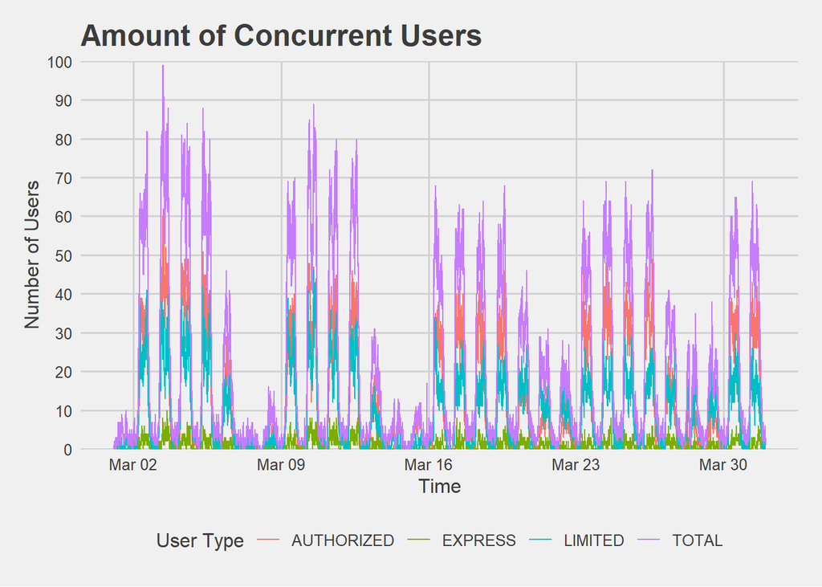

```r
  #Creates time series chart showing the number of concurrent users per minute
  ggplot(finalfinal) +
    geom_line(aes(x=interval,y=x_auth,color='AUTHORIZED')) +
    geom_line(aes(x=interval,y=x_exp,color='EXPRESS')) +
    geom_line(aes(x=interval,y=x_lim,color='LIMITED')) +
    geom_line(aes(x=interval,y=total,color='TOTAL')) +
    labs(title="Amount of Concurrent Users",x="Time",y="Number of Users",color='User Type') +
    scale_y_continuous(limits=c(0,100),breaks=seq(0,100,10),expand=c(0,0)) +
    theme_fivethirtyeight() +
    theme(axis.title=element_text())
```

Now we can see clearly that most users log in during business hours and more users were active in the beginning of the month. We can also see that the majority of active users are under the AUTHORIZED user type and the minority of users are under the EXPRESS user type.